# Obtaining natural ranges for plants species on POWO

Joao Vidal

7/22/2022

### Installing and loading the packages

This tutorial guides you on retrieving shapefiles and individual the range distributions of plant species from the Plants of the World Online website (https://powo.science.kew.org/) using a little bit of html scrapping and the kewr API (https://github.com/barnabywalker/kewr/). All you need is a species list with valid names and the code will look for it on the website and return the natural range as a string and the respective shapefile, saving you a lot of time if you are working with a lot of species. We will also plot some maps to check out the results.

First we install and load the necessary packages.

```r
install.packages(c("remotes", "httr", "terra"),repos = "http://cran.us.r-project.org")
remotes::install_github("barnabywalker/kewr")
library(kewr)
library(httr)
```

Then we set the working directory and load some example data.

```r
# Set wd
setwd("E:/Geographic datasets/")

# Create a species list
dataset <- data.frame("species"=c("Rauvolfia ligustrina",
                                  "Rauvolfia andina",
                                  "Rauvolfia vomitoria"))
dataset$species <- as.factor(dataset$species)

# Creates a dataframe to store the results
ranges_spp <- cbind.data.frame("species"=as.factor(levels(dataset$species)), "native_range"=NA)

# Removes the original object to save memory (usefull in case you have a huge dataset)
remove(dataset)
```

### Retrieving the url and searching for the range information

The following loop was written by myself and iterates over the dataframe to find the url for the species using the function search_powo() from the kewr package. Then, the function readLines() is used to read the html, and we use grep() to identify the lines where the range information is listed. Not all taxa include range information, so this code only works if the taxon is valid and includes range information. Otherwise, the loop will skip the non-valid taxa and look for the next one on the list.

```r
i <- 1
j <- 1

for(i in j:nrow(ranges_spp)){
  # First we use the API from kewr to find each species url in the Powo website
  results <- search_powo(ranges_spp[i,]$species)

  # This creates the url string to be retrieved for each species
  url <- paste0("https://powo.science.kew.org",results$results[[1]]$url)

  # This reads the html file
  x <- readLines(url)

  # Identify the line where the range is described
  index_i <- grep('Native to:',x)

  # Create a conditional to only run the rest of the code for species with range information
  if(length(index_i)>0){
   # Creates two variables to store the beginning and the end of the distribution range text
    index_j <- grep('</p>',x)
    index_j <- index_j[index_j>index_i][1]

    # Some regular expressions to remove the html quotation and the extra spaces in the text
    res <- gsub(".*<p>", "", paste(x[index_i:index_j[1]], collapse = ''))
    res <- gsub("  +", "", res)
    res <- gsub("</p>", "", res)

    # Removes special characters
    res <- iconv(res, from = 'UTF-8', to = 'ASCII//TRANSLIT')
    ranges_spp[i,]$native_range <- res
  }
}
```

We can now inspect the results:

```r
head(ranges_spp)
```

```
##                species
## 1     Rauvolfia andina
## 2 Rauvolfia ligustrina
## 3  Rauvolfia vomitoria
##                                                                                                                                                                                                                                          native_range
## 1                                                                                                                                                                                                                                                Peru
## 2 Argentina Northeast,Belize,Bolivia,Brazil North,Brazil Northeast,Brazil Southeast,Brazil West-Central,Colombia,Costa Rica,Cuba,El Salvador,Guatemala,Guyana,Mexico Southeast,Mexico Southwest,Nicaragua,Paraguay,Suriname,Trinidad-Tobago,Venezuela
## 3                       Angola,Benin,Burkina,Cabinda,Cameroon,Central African Repu,Congo,Equatorial Guinea,Gabon,Ghana,Guinea,Guinea-Bissau,Gulf of Guinea Is.,Ivory Coast,Liberia,Mali,Nigeria,Senegal,Sierra Leone,Sudan,Tanzania,Togo,Uganda,Zaire
```

### Obtaining shapefiles and plotting individual maps

We can use the ranges obtained on the previous step to plot maps and export the shapefiles. For that, we will use the terra package (Hijmans (2022), https://CRAN.R-project.org/package=terra). We will need to download the World Geographical Scheme for Recording Plant Distributions (WGSRPD) shapefile from the Biodiversity Information Standards (TDWG) github repository (https://github.com/tdwg) using the code bellow.

```r
# Load terra package to handle spatial files
library(terra)
temp <- tempfile()
temp2 <- tempfile()
download.file("https://github.com/tdwg/wgsrpd/archive/refs/heads/master.zip",temp)
unzip(zipfile = temp, exdir = temp2)
tdwg <- vect(file.path(temp2, "wgsrpd-master/level3/level3.shp"))
unlink(temp)
# Remove special characters to standartize the names
tdwg$LEVEL3_NAM <- iconv(tdwg$LEVEL3_NAM, from = 'UTF-8', to = 'ASCII//TRANSLIT')
```

We can also plot some maps to visualize the distributions. There are many tutorials out there on how to plot fancy maps, this is just a basic automatized visualization. We will subset the shapefile provided by TDWG and use the original one as a base plot.

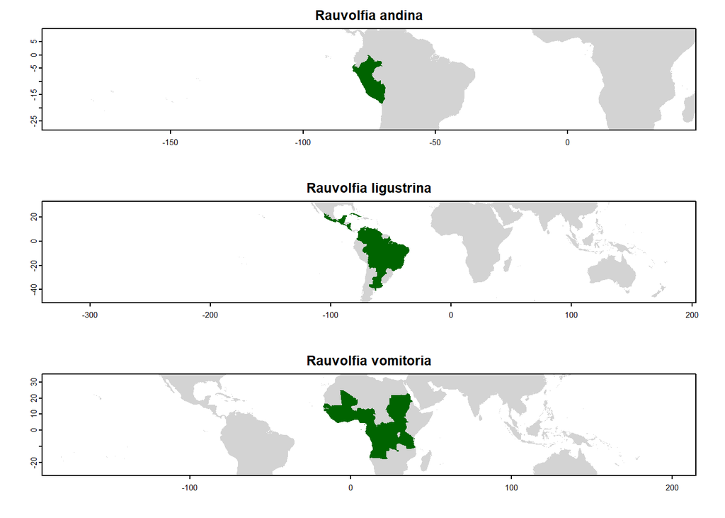

```r
# Defines a plot grid
par(mfrow=c(nrow(ranges_spp),1))

# Creates the loop
for(i in 1:nrow(ranges_spp)){
  # Subsets the TDWG shapefile to the range of our species of interest
  range_shp <- tdwg[tdwg$LEVEL3_NAM%in%unlist(strsplit(ranges_spp[i,]$native_range, ",")),]

  # Creates a base plot using the extent of the distribution shapefile we just created
  plot(tdwg, xlim=c(ext(range_shp)[1]-10, ext(range_shp)[2]+10), ylim=c(ext(range_shp)[3]-10, ext(range_shp)[4]+10), col="light grey", lty=0, main=ranges_spp[i,]$species)

  # Plots the range
  plot(range_shp, col="dark green", lty=0, add=T)
}
```

Finally, we can export the shapefiles to use, for example, as a mask for species distribution models. This example saves the last one retrieved on the previous step. To save all the resulting shapefiles, just include this code within the previous for() loop.

```r
# To export the shapefiles, use writeVector()
writeVector(range_shp, paste0(ranges_spp[i,]$species,".shp"), overwrite=TRUE)
```